# Assignment 3: Relationships

Julia Meinhardt

9/20/2020

```r
bay_data <- read_csv("baytractdata2018.csv")
jefferson_data <- read_csv("jeffersontractdata2018.csv")
combined_data <- read_csv("jeffersonbay2018.csv")
```

## Topic and Variables

My data analysis uses tract-level data to explore poverty, public assistance, and high-school graduation rates in two regions of California: the Bay Area and an informal region called “Jefferson” comprised of rural counties in Northeast California. Jefferson is a primarily rural region, while the Bay Area is primarily urban.

I have quite a large set of variables, most of which are continuous. Part of this is because I’ve chosen to look at all three poverty variables as defined by the 5-Year ACS as well as differences in public assistance including and excluding Social Security Income.

**List of Variables**

1. Total Population: total_popE = (continuous)
2. Total below 150 % poverty level: low_income (continuous)
3. Percent of population receiving public assistance (including SSI): (continuous)
4. Percent of population receiving cash public assistance (including food stamps/SNAP): (continuous)
5. High School Graduates: (categorical, >83% meets statewide average)
6. Some college or Associates: (categorical, >29% meets statewide average)
7. Bachelors or higher: (categorical, >33% meets statewide average)
8. County (categorical)
9. Region (categorical)

#### Organization and Credit

Because I’ve chosen a large number of continuous variables and per the assignment instructions to test every possible relationship, there are quite a few calculations in this analysis. To make the document readable and emphasize salient information, my code chunks are all collapsible. If the reader would like to view all the code, you can use the code button at the top right corner of the screen to turn all code on or off. Additionally, you can view individual code chunks as desired by clicking the code button above the output for which you’d like to see the code.

Tabs are organized by the type of test being performed. Within each tab, calculations are organized by whether or not they are being performed on the Bay Area Region data, Jefferson Region data, or both regions combined.

The relationships between all variables as shown by the tests are all described in the **Relationship Strengths and Statistical Significance** tab. The calculations I’ve chosen to visualize and analyze are in the **Discussion, Visualizations, and Comparisons** tab.

I used **Cat’s** example and **Carole’s** tutorial as the basis for organization and exploration. **Dylan** shared a code function with me that allowed me to visualize my correlations in one table, which was extremely useful for visualizing correlations in one space. **Mel** shared the code for creating a floating table of contents in our Tuesday class meeting, which ended up being so essential for organizing this analysis in a way that was manageable. And **Ryan** reminded me that this was assignment 3 and not 2… Thanks all!

## Tests, Analysis, and Visualizations

### Pearson’s Correlation Calculations

#### Bay Area Correlations Summary Table:

```r
cor(bay_data[,unlist(lapply(bay_data, is.numeric))])
```

```
##              low_income  total_popE  pub_assist cash_assist
## low_income   1.00000000 -0.02909065 -0.02729313  0.79640146
## total_popE  -0.02909065  1.00000000 -0.25710636 -0.03438061
## pub_assist  -0.02729313 -0.25710636  1.00000000 -0.03912450
## cash_assist  0.79640146 -0.03438061 -0.03912450  1.00000000
```

#### Jefferson Correlations Summary Table:

```r
cor(jefferson_data[,unlist(lapply(jefferson_data, is.numeric))])
```

```
##             low_income   total_popE pub_assist  cash_assist
## low_income   1.0000000 -0.181073338  0.2737711  0.656851973
## total_popE  -0.1810733  1.000000000 -0.4897601 -0.009075825
## pub_assist   0.2737711 -0.489760062  1.0000000  0.245708109
## cash_assist  0.6568520 -0.009075825  0.2457081  1.000000000
```

The remainder of this tab shows individual correlations in more detail. These will be explored further in the **Visualizations, Comparisons, and Analysis** tab.

#### Individual Bay Correlations

```r
correlation1_bay <- cor.test(bay_data$total_popE, bay_data$low_income)
correlation1_bay
```

```
##
##  Pearson's product-moment correlation
##
## data:  bay_data$total_popE and bay_data$low_income
## t = -1.1557, df = 1577, p-value = 0.248
## alternative hypothesis: true correlation is not equal to 0
## 95 percent confidence interval:
##  -0.07830898  0.02026914
## sample estimates:
##         cor
## -0.02909065
```

```r
correlation2_bay <- cor.test(bay_data$total_popE, bay_data$pub_assist)
correlation2_bay
```

```
##
##  Pearson's product-moment correlation
##
## data:  bay_data$total_popE and bay_data$pub_assist
## t = -10.565, df = 1577, p-value < 2.2e-16
## alternative hypothesis: true correlation is not equal to 0
## 95 percent confidence interval:
##  -0.3025991 -0.2104448
## sample estimates:
##        cor
## -0.2571064
```

```r
correlation3_bay <- cor.test(bay_data$total_popE, bay_data$cash_assist)
correlation3_bay
```

```
##
##  Pearson's product-moment correlation
##
## data:  bay_data$total_popE and bay_data$cash_assist
## t = -1.3661, df = 1577, p-value = 0.1721
## alternative hypothesis: true correlation is not equal to 0
## 95 percent confidence interval:
##  -0.08356958  0.01497549
## sample estimates:
##         cor
## -0.03438061
```

```r
correlation4_bay <- cor.test(bay_data$low_income, bay_data$pub_assist)
correlation4_bay
```

```
##
##  Pearson's product-moment correlation
##
## data:  bay_data$low_income and bay_data$pub_assist
## t = -1.0843, df = 1577, p-value = 0.2784
## alternative hypothesis: true correlation is not equal to 0
## 95 percent confidence interval:
##  -0.07652081  0.02206728
## sample estimates:
##         cor
## -0.02729313
```

```r
correlation5_bay <- cor.test(bay_data$low_income, bay_data$cash_assist)
correlation5_bay
```

```
##
##  Pearson's product-moment correlation
##
## data:  bay_data$low_income and bay_data$cash_assist
## t = 52.295, df = 1577, p-value < 2.2e-16
## alternative hypothesis: true correlation is not equal to 0
## 95 percent confidence interval:
##  0.7776212 0.8137619
## sample estimates:
##       cor
## 0.7964015
```

```r
correlation6_bay <- cor.test(bay_data$cash_assist, bay_data$pub_assist)
correlation6_bay
```

```
##
##  Pearson's product-moment correlation
##
## data:  bay_data$cash_assist and bay_data$pub_assist
## t = -1.5549, df = 1577, p-value = 0.1202
## alternative hypothesis: true correlation is not equal to 0
## 95 percent confidence interval:
##  -0.08828482  0.01022594
## sample estimates:
##        cor
## -0.0391245
```

#### Individual Jefferson Correlations

```r
correlation1_jefferson <- cor.test(jefferson_data$total_popE, jefferson_data$low_income)
correlation1_jefferson
```

```
##
##  Pearson's product-moment correlation
##
## data:  jefferson_data$total_popE and jefferson_data$low_income
## t = -1.766, df = 92, p-value = 0.08072
## alternative hypothesis: true correlation is not equal to 0
## 95 percent confidence interval:
##  -0.37011146  0.02236413
## sample estimates:
##        cor
## -0.1810733
```

```r
correlation2_jefferson <- cor.test(jefferson_data$total_popE, jefferson_data$pub_assist)
correlation2_jefferson
```

```
##
##  Pearson's product-moment correlation
##
## data:  jefferson_data$total_popE and jefferson_data$pub_assist
## t = -5.3881, df = 92, p-value = 5.448e-07
## alternative hypothesis: true correlation is not equal to 0
## 95 percent confidence interval:
##  -0.6298725 -0.3187765
## sample estimates:
##        cor
## -0.4897601
```

```r
correlation3_jefferson <- cor.test(jefferson_data$total_popE, jefferson_data$cash_assist)
correlation3_jefferson
```

```
##
##  Pearson's product-moment correlation
##
## data:  jefferson_data$total_popE and jefferson_data$cash_assist
## t = -0.087056, df = 92, p-value = 0.9308
## alternative hypothesis: true correlation is not equal to 0
## 95 percent confidence interval:
##  -0.2113042  0.1938977
## sample estimates:
##          cor
## -0.009075825
```

```r
correlation4_jefferson <- cor.test(jefferson_data$low_income, jefferson_data$pub_assist)
correlation4_jefferson
```

```
##
##  Pearson's product-moment correlation
##
## data:  jefferson_data$low_income and jefferson_data$pub_assist
## t = 2.7302, df = 92, p-value = 0.007585
## alternative hypothesis: true correlation is not equal to 0
## 95 percent confidence interval:
##  0.07533292 0.45135132
## sample estimates:
##       cor
## 0.2737711
```

```r
correlation5_jefferson <- cor.test(jefferson_data$low_income, jefferson_data$cash_assist)
correlation5_jefferson
```

```
##
##  Pearson's product-moment correlation
##
## data:  jefferson_data$low_income and jefferson_data$cash_assist
## t = 8.3556, df = 92, p-value = 6.527e-13
## alternative hypothesis: true correlation is not equal to 0
## 95 percent confidence interval:
##  0.5239698 0.7585182
## sample estimates:
##      cor
## 0.656852
```

```r
correlation6_jefferson <- cor.test(jefferson_data$cash_assist, jefferson_data$pub_assist)
correlation6_jefferson
```

```
##
##  Pearson's product-moment correlation
##
## data:  jefferson_data$cash_assist and jefferson_data$pub_assist
## t = 2.4313, df = 92, p-value = 0.01698
## alternative hypothesis: true correlation is not equal to 0
## 95 percent confidence interval:
##  0.04534882 0.42706386
## sample estimates:
##       cor
## 0.2457081
```

### Two-Sample T-Test Calculations

#### Bay Area T-Test Calculations:

```r
difference1_bay = t.test(total_popE~ majority_grads,
                    data = bay_data)
difference1_bay
```

```
##
##  Welch Two Sample t-test
##
## data:  total_popE by majority_grads
## t = 0.9108, df = 247.24, p-value = 0.3633
## alternative hypothesis: true difference in means is not equal to 0
## 95 percent confidence interval:
##  -150.8449  410.3655
## sample estimates:
## mean in group FALSE  mean in group TRUE
##            4975.241            4845.481
```

```r
difference2_bay = t.test(low_income ~ majority_grads,
                    data = bay_data)
difference2_bay
```

```
##
##  Welch Two Sample t-test
##
## data:  low_income by majority_grads
## t = 20.181, df = 225.08, p-value < 2.2e-16
## alternative hypothesis: true difference in means is not equal to 0
## 95 percent confidence interval:
##  0.1523894 0.1853688
## sample estimates:
## mean in group FALSE  mean in group TRUE
##           0.2985546           0.1296755
```

```r
difference3_bay = t.test(pub_assist ~ majority_grads ,
                    data = bay_data)
difference3_bay
```

```
##
##  Welch Two Sample t-test
##
## data:  pub_assist by majority_grads
## t = -10.316, df = 229.26, p-value < 2.2e-16
## alternative hypothesis: true difference in means is not equal to 0
## 95 percent confidence interval:
##  -0.08610379 -0.05848684
## sample estimates:
## mean in group FALSE  mean in group TRUE
##           0.2984234           0.3707187
```

```r
difference4_bay = t.test(cash_assist ~ majority_grads ,
                    data = bay_data)
difference4_bay
```

```
##
##  Welch Two Sample t-test
##
## data:  cash_assist by majority_grads
## t = 16.913, df = 234.62, p-value < 2.2e-16
## alternative hypothesis: true difference in means is not equal to 0
## 95 percent confidence interval:
##  0.02484447 0.03139549
## sample estimates:
## mean in group FALSE  mean in group TRUE
##          0.04832071          0.02020073
```

```r
difference5_bay = t.test(total_popE~ majority_college,
                    data = bay_data)
difference5_bay
```

```
##
##  Welch Two Sample t-test
##
## data:  total_popE by majority_college
## t = 0.21377, df = 71.526, p-value = 0.8313
## alternative hypothesis: true difference in means is not equal to 0
## 95 percent confidence interval:
##  -396.6521  491.9272
## sample estimates:
## mean in group FALSE  mean in group TRUE
##            4863.168            4815.530
```

```r
difference6_bay = t.test(low_income ~ majority_college,
                    data = bay_data)
difference6_bay
```

```
##
##  Welch Two Sample t-test
##
## data:  low_income by majority_college
## t = 1.4027, df = 86.35, p-value = 0.1643
## alternative hypothesis: true difference in means is not equal to 0
## 95 percent confidence interval:
##  -0.004492387  0.026032556
## sample estimates:
## mean in group FALSE  mean in group TRUE
##           0.1505538           0.1397837
```

```r
difference7_bay = t.test(pub_assist ~ majority_college,
                    data = bay_data)
difference7_bay
```

```
##
##  Welch Two Sample t-test
##
## data:  pub_assist by majority_college
## t = -0.90215, df = 74.623, p-value = 0.3699
## alternative hypothesis: true difference in means is not equal to 0
## 95 percent confidence interval:
##  -0.024273510  0.009142053
## sample estimates:
## mean in group FALSE  mean in group TRUE
##           0.3616574           0.3692231
```

```r
difference8_bay = t.test(cash_assist ~ majority_college,
                    data = bay_data)
difference8_bay
```

```
##
##  Welch Two Sample t-test
##
## data:  cash_assist by majority_college
## t = -0.39519, df = 76.308, p-value = 0.6938
## alternative hypothesis: true difference in means is not equal to 0
## 95 percent confidence interval:
##  -0.004895738  0.003274486
## sample estimates:
## mean in group FALSE  mean in group TRUE
##          0.02356832          0.02437894
```

```r
difference9_bay = t.test(total_popE~ majority_bachelors,
                    data = bay_data)
difference9_bay
```

```
##
##  Welch Two Sample t-test
##
## data:  total_popE by majority_bachelors
## t = 4.0015, df = 1554.5, p-value = 6.59e-05
## alternative hypothesis: true difference in means is not equal to 0
## 95 percent confidence interval:
##  191.3527 559.3290
## sample estimates:
## mean in group FALSE  mean in group TRUE
##            5036.843            4661.502
```

```r
difference10_bay = t.test(low_income ~ majority_bachelors,
                    data = bay_data)
difference10_bay
```

```
##
##  Welch Two Sample t-test
##
## data:  low_income by majority_bachelors
## t = 18.165, df = 1421.7, p-value < 2.2e-16
## alternative hypothesis: true difference in means is not equal to 0
## 95 percent confidence interval:
##  0.07782971 0.09667488
## sample estimates:
## mean in group FALSE  mean in group TRUE
##           0.1909392           0.1036869
```

```r
difference11_bay = t.test(pub_assist ~ majority_bachelors,
                    data = bay_data)
difference11_bay
```

```
##
##  Welch Two Sample t-test
##
## data:  pub_assist by majority_bachelors
## t = -19.977, df = 1421.2, p-value < 2.2e-16
## alternative hypothesis: true difference in means is not equal to 0
## 95 percent confidence interval:
##  -0.08354823 -0.06860703
## sample estimates:
## mean in group FALSE  mean in group TRUE
##           0.3263680           0.4024456
```

```r
difference12_bay = t.test(cash_assist ~ majority_bachelors,
                    data = bay_data)
difference12_bay
```

```
##
##  Welch Two Sample t-test
##
## data:  cash_assist by majority_bachelors
## t = 19.107, df = 1377.9, p-value < 2.2e-16
## alternative hypothesis: true difference in means is not equal to 0
## 95 percent confidence interval:
##  0.01666821 0.02048238
## sample estimates:
## mean in group FALSE  mean in group TRUE
##          0.03229577          0.01372047
```

#### Jefferson T-Test Calculations:

```r
difference1_jefferson = t.test(total_popE~ majority_grads,
                    data = jefferson_data)
difference1_jefferson
```

```
##
##  Welch Two Sample t-test
##
## data:  total_popE by majority_grads
## t = 0.63398, df = 3.0395, p-value = 0.5706
## alternative hypothesis: true difference in means is not equal to 0
## 95 percent confidence interval:
##  -4904.968  7367.890
## sample estimates:
## mean in group FALSE  mean in group TRUE
##            4601.750            3370.289
```

```r
difference2_jefferson = t.test(low_income ~ majority_grads,
                    data = jefferson_data)
difference2_jefferson
```

```
##
##  Welch Two Sample t-test
##
## data:  low_income by majority_grads
## t = 0.056451, df = 3.052, p-value = 0.9585
## alternative hypothesis: true difference in means is not equal to 0
## 95 percent confidence interval:
##  -0.3522675  0.3651155
## sample estimates:
## mean in group FALSE  mean in group TRUE
##           0.2763046           0.2698806
```

```r
difference3_jefferson = t.test(pub_assist ~ majority_grads ,
                    data = jefferson_data)
difference3_jefferson
```

```
##
##  Welch Two Sample t-test
##
## data:  pub_assist by majority_grads
## t = -1.9388, df = 3.0219, p-value = 0.1472
## alternative hypothesis: true difference in means is not equal to 0
## 95 percent confidence interval:
##  -0.40495302  0.09756204
## sample estimates:
## mean in group FALSE  mean in group TRUE
##           0.2602552           0.4139507
```

```r
difference4_jefferson = t.test(cash_assist ~ majority_grads ,
                    data = jefferson_data)
difference4_jefferson
```

```
##
##  Welch Two Sample t-test
##
## data:  cash_assist by majority_grads
## t = -1.1635, df = 3.3689, p-value = 0.3204
## alternative hypothesis: true difference in means is not equal to 0
## 95 percent confidence interval:
##  -0.04674899  0.02058341
## sample estimates:
## mean in group FALSE  mean in group TRUE
##          0.03535144          0.04843423
```

```r
difference5_jefferson = t.test(total_popE~ majority_college,
                    data = jefferson_data)
difference5_jefferson
```

```
##
##  Welch Two Sample t-test
##
## data:  total_popE by majority_college
## t = 0.24182, df = 75.43, p-value = 0.8096
## alternative hypothesis: true difference in means is not equal to 0
## 95 percent confidence interval:
##  -612.7621  782.0967
## sample estimates:
## mean in group FALSE  mean in group TRUE
##            3473.132            3388.464
```

```r
difference6_jefferson = t.test(low_income ~ majority_college,
                    data = jefferson_data)
difference6_jefferson
```

```
##
##  Welch Two Sample t-test
##
## data:  low_income by majority_college
## t = 1.4347, df = 63.907, p-value = 0.1563
## alternative hypothesis: true difference in means is not equal to 0
## 95 percent confidence interval:
##  -0.01315765  0.08019972
## sample estimates:
## mean in group FALSE  mean in group TRUE
##           0.2901240           0.2566029
```

```r
difference7_jefferson = t.test(pub_assist ~ majority_college,
                    data = jefferson_data)
difference7_jefferson
```

```
##
##  Welch Two Sample t-test
##
## data:  pub_assist by majority_college
## t = -2.9205, df = 60.398, p-value = 0.004908
## alternative hypothesis: true difference in means is not equal to 0
## 95 percent confidence interval:
##  -0.06483652 -0.01212849
## sample estimates:
## mean in group FALSE  mean in group TRUE
##           0.3844847           0.4229672
```

```r
difference8_jefferson = t.test(cash_assist ~ majority_college,
                    data = jefferson_data)
difference8_jefferson
```

```
##
##  Welch Two Sample t-test
##
## data:  cash_assist by majority_college
## t = 0.61416, df = 58.076, p-value = 0.5415
## alternative hypothesis: true difference in means is not equal to 0
## 95 percent confidence interval:
##  -0.007983462  0.015051027
## sample estimates:
## mean in group FALSE  mean in group TRUE
##          0.04998275          0.04644897
```

```r
difference9_jefferson = t.test(total_popE~ majority_bachelors,
                    data = jefferson_data)
difference9_jefferson
```

```
##
##  Welch Two Sample t-test
##
## data:  total_popE by majority_bachelors
## t = 2.6778, df = 1.1958, p-value = 0.1933
## alternative hypothesis: true difference in means is not equal to 0
## 95 percent confidence interval:
##  -3507.859  6624.555
## sample estimates:
## mean in group FALSE  mean in group TRUE
##            3455.848            1897.500
```

```r
difference10_jefferson = t.test(low_income ~ majority_bachelors,
                    data = jefferson_data)
difference10_jefferson
```

```
##
##  Welch Two Sample t-test
##
## data:  low_income by majority_bachelors
## t = 5.8464, df = 1.2859, p-value = 0.07007
## alternative hypothesis: true difference in means is not equal to 0
## 95 percent confidence interval:
##  -0.0563265  0.4232572
## sample estimates:
## mean in group FALSE  mean in group TRUE
##          0.27405750          0.09059218
```

```r
difference11_jefferson = t.test(pub_assist ~ majority_bachelors,
                    data = jefferson_data)
difference11_jefferson
```

```
##
##  Welch Two Sample t-test
##
## data:  pub_assist by majority_bachelors
## t = -0.63972, df = 1.0251, p-value = 0.6356
## alternative hypothesis: true difference in means is not equal to 0
## 95 percent confidence interval:
##  -0.7250645  0.6516422
## sample estimates:
## mean in group FALSE  mean in group TRUE
##           0.4066293           0.4433405
```

```r
difference12_jefferson = t.test(cash_assist ~ majority_bachelors,
                    data = jefferson_data)
difference12_jefferson
```

```
##
##  Welch Two Sample t-test
##
## data:  cash_assist by majority_bachelors
## t = 5.6325, df = 2.8497, p-value = 0.01269
## alternative hypothesis: true difference in means is not equal to 0
## 95 percent confidence interval:
##  0.009691677 0.036708644
## sample estimates:
## mean in group FALSE  mean in group TRUE
##          0.04837114          0.02517098
```

#### Bay and Jefferson Combined T-Test Calculations:

```r
difference1_combined = t.test(total_popE ~ region,
                    data = combined_data)
difference1_combined
```

```
##
##  Welch Two Sample t-test
##
## data:  total_popE by region
## t = 8.2249, df = 108.04, p-value = 4.769e-13
## alternative hypothesis: true difference in means is not equal to 0
## 95 percent confidence interval:
##  1091.817 1785.154
## sample estimates:
##       mean in group Bay mean in group Jefferson
##                4861.177                3422.691
```

```r
difference2_combined = t.test(low_income ~ region,
                    data = combined_data)
difference2_combined
```

```
##
##  Welch Two Sample t-test
##
## data:  low_income by region
## t = -10.674, df = 104.68, p-value < 2.2e-16
## alternative hypothesis: true difference in means is not equal to 0
## 95 percent confidence interval:
##  -0.14235279 -0.09774803
## sample estimates:
##       mean in group Bay mean in group Jefferson
##               0.1501036               0.2701540
```

```r
difference3_combined = t.test(cash_assist ~ region,
                    data = combined_data)
difference3_combined
```

```
##
##  Welch Two Sample t-test
##
## data:  cash_assist by region
## t = -9.1257, df = 101.55, p-value = 7.236e-15
## alternative hypothesis: true difference in means is not equal to 0
## 95 percent confidence interval:
##  -0.02955188 -0.01899876
## sample estimates:
##       mean in group Bay mean in group Jefferson
##              0.02360220              0.04787752
```

```r
difference4_combined = t.test(pub_assist ~ region,
                    data = combined_data)
difference4_combined
```

```
##
##  Welch Two Sample t-test
##
## data:  pub_assist by region
## t = -6.8287, df = 114.74, p-value = 4.313e-10
## alternative hypothesis: true difference in means is not equal to 0
## 95 percent confidence interval:
##  -0.05861690 -0.03225665
## sample estimates:
##       mean in group Bay mean in group Jefferson
##               0.3619737               0.4074104
```

### Chi-square test

#### Bay and Jefferson Combined Chi-square Calculations:

Because region and county are the categorical variables I’m comparing with my high school graduation variable, I’ve chosen to perform the tests with the combined data.

```r
chi1_combined <- chisq.test(combined_data$region, combined_data$majority_grads)
chi1_combined
```

```
##
##  Pearson's Chi-squared test with Yates' continuity correction
##
## data:  combined_data$region and combined_data$majority_grads
## X-squared = 4.5629, df = 1, p-value = 0.03267
```

```r
chi1_combined$observed
```

```
##                     combined_data$majority_grads
## combined_data$region FALSE TRUE
##            Bay         191 1388
##            Jefferson     4   90
```

```r
chi1_combined$expected
```

```
##                     combined_data$majority_grads
## combined_data$region     FALSE       TRUE
##            Bay       184.04363 1394.95637
##            Jefferson  10.95637   83.04363
```

```r
chi2_combined <- chisq.test(combined_data$region, combined_data$majority_college)
chi2_combined
```

```
##
##  Pearson's Chi-squared test with Yates' continuity correction
##
## data:  combined_data$region and combined_data$majority_college
## X-squared = 394.54, df = 1, p-value < 2.2e-16
```

```r
chi2_combined$observed
```

```
##                     combined_data$majority_college
## combined_data$region FALSE TRUE
##            Bay        1513   66
##            Jefferson    38   56
```

```r
chi2_combined$expected
```

```
##                     combined_data$majority_college
## combined_data$region      FALSE       TRUE
##            Bay       1463.85475 115.145248
##            Jefferson   87.14525   6.854752
```

```r
chi3_combined <- chisq.test(combined_data$region, combined_data$majority_bachelors)
chi3_combined
```

```
##
##  Pearson's Chi-squared test with Yates' continuity correction
##
## data:  combined_data$region and combined_data$majority_bachelors
## X-squared = 69.961, df = 1, p-value < 2.2e-16
```

```r
chi3_combined$observed
```

```
##
## combined_data$region FALSE TRUE
##            Bay         840  739
##            Jefferson    92    2
```

```r
chi3_combined$expected
```

```
##
## combined_data$region     FALSE      TRUE
##            Bay       879.63419 699.36581
##            Jefferson  52.36581  41.63419
```

```r
chi4_combined <- chisq.test(combined_data$county, combined_data$majority_grads)
chi4_combined
```

```
##
##  Pearson's Chi-squared test
##
## data:  combined_data$county and combined_data$majority_grads
## X-squared = 25.969, df = 15, p-value = 0.03835
```

```r
chi4_combined$observed
```

```
##                     combined_data$majority_grads
## combined_data$county FALSE TRUE
##        Alameda          49  311
##        ContraCosta      21  186
##        Del Norte         1    6
##        Lassen            1    8
##        Marin             3   52
##        Modoc             0    4
##        Napa              3   37
##        Plumas            0    7
##        San Francisco    31  164
##        San Mateo        15  141
##        Santa Clara      56  316
##        Shasta            0   48
##        Siskiyou          2   12
##        Solano            6   89
##        Sonoma            7   92
##        Trinity           0    5
```

```r
chi4_combined$expected
```

```
##                     combined_data$majority_grads
## combined_data$county      FALSE       TRUE
##        Alameda       41.9605499 318.039450
##        ContraCosta   24.1273162 182.872684
##        Del Norte      0.8158996   6.184100
##        Lassen         1.0490137   7.950986
##        Marin          6.4106396  48.589360
##        Modoc          0.4662283   3.533772
##        Napa           4.6622833  35.337717
##        Plumas         0.8158996   6.184100
##        San Francisco 22.7286312 172.271369
##        San Mateo     18.1829050 137.817095
##        Santa Clara   43.3592349 328.640765
##        Shasta         5.5947400  42.405260
##        Siskiyou       1.6317992  12.368201
##        Solano        11.0729229  83.927077
##        Sonoma        11.5391512  87.460849
##        Trinity        0.5827854   4.417215
```

```r
chi5_combined <- chisq.test(combined_data$county, combined_data$majority_college)
chi5_combined
```

```
##
##  Pearson's Chi-squared test
##
## data:  combined_data$county and combined_data$majority_college
## X-squared = 567.42, df = 15, p-value < 2.2e-16
```

```r
chi5_combined$observed
```

```
##                     combined_data$majority_college
## combined_data$county FALSE TRUE
##        Alameda         356    4
##        ContraCosta     193   14
##        Del Norte         6    1
##        Lassen            3    6
##        Marin            55    0
##        Modoc             3    1
##        Napa             37    3
##        Plumas            0    7
##        San Francisco   195    0
##        San Mateo       154    2
##        Santa Clara     371    1
##        Shasta           18   30
##        Siskiyou          6    8
##        Solano           70   25
##        Sonoma           82   17
##        Trinity           2    3
```

```r
chi5_combined$expected
```

```
##                     combined_data$majority_college
## combined_data$county      FALSE       TRUE
##        Alameda       333.747759 26.2522415
##        ContraCosta   191.904961 15.0950389
##        Del Norte       6.489540  0.5104603
##        Lassen          8.343694  0.6563060
##        Marin          50.989241  4.0107591
##        Modoc           3.708308  0.2916916
##        Napa           37.083084  2.9169157
##        Plumas          6.489540  0.5104603
##        San Francisco 180.780036 14.2199641
##        San Mateo     144.624029 11.3759713
##        Santa Clara   344.872684 27.1273162
##        Shasta         44.499701  3.5002989
##        Siskiyou       12.979079  1.0209205
##        Solano         88.072325  6.9276748
##        Sonoma         91.780634  7.2193664
##        Trinity         4.635386  0.3646145
```

```r
chi6_combined <- chisq.test(combined_data$county, combined_data$majority_bachelors)
chi6_combined
```

```
##
##  Pearson's Chi-squared test
##
## data:  combined_data$county and combined_data$majority_bachelors
## X-squared = 259.83, df = 15, p-value < 2.2e-16
```

```r
chi6_combined$observed
```

```
##
## combined_data$county FALSE TRUE
##        Alameda         201  159
##        ContraCosta     119   88
##        Del Norte         7    0
##        Lassen            9    0
##        Marin            12   43
##        Modoc             4    0
##        Napa             31    9
##        Plumas            6    1
##        San Francisco    46  149
##        San Mateo        61   95
##        Santa Clara     210  162
##        Shasta           47    1
##        Siskiyou         14    0
##        Solano           84   11
##        Sonoma           76   23
##        Trinity           5    0
```

```r
chi6_combined$expected
```

```
##
## combined_data$county      FALSE       TRUE
##        Alameda       200.549910 159.450090
##        ContraCosta   115.316198  91.683802
##        Del Norte       3.899582   3.100418
##        Lassen          5.013748   3.986252
##        Marin          30.639570  24.360430
##        Modoc           2.228332   1.771668
##        Napa           22.283323  17.716677
##        Plumas          3.899582   3.100418
##        San Francisco 108.631201  86.368799
##        San Mateo      86.904961  69.095039
##        Santa Clara   207.234907 164.765093
##        Shasta         26.739988  21.260012
##        Siskiyou        7.799163   6.200837
##        Solano         52.922893  42.077107
##        Sonoma         55.151225  43.848775
##        Trinity         2.785415   2.214585
```

### Analysis of Variance (ANOVA)

#### Bay Area ANOVA Tests

##### County and Low Income

```r
anova1_bay <- aov (low_income ~ county, data = bay_data)
summary(anova1_bay)
```

```
##               Df Sum Sq Mean Sq F value   Pr(>F)
## county         8  0.773 0.09668    8.74 9.59e-12 ***
## Residuals   1570 17.366 0.01106
## ---
## Signif. codes:  0 '***' 0.001 '**' 0.01 '*' 0.05 '.' 0.1 ' ' 1
```

```r
differences1_bay <- TukeyHSD(anova1_bay)
summary(differences1_bay)
```

```
##        Length Class  Mode
## county 144    -none- numeric
```

```r
as_tibble(cbind(pair = row.names(differences1_bay$county),
                differences1_bay$county))
```

```
## # A tibble: 36 x 5
##    pair             diff            lwr           upr            `p adj`
##    <chr>            <chr>           <chr>         <chr>          <chr>
##  1 ContraCosta-Ala… -0.01632509340… -0.044820109… 0.01216992241… 0.695901855810…
##  2 Marin-Alameda    -0.05045622723… -0.097750140… -0.0031623140… 0.026287578931…
##  3 Napa-Alameda     -0.02553087021… -0.079976439… 0.02891469939… 0.875261051958…
##  4 San Francisco-A… 0.002506064906… -0.026540296… 0.03155242596… 0.999999221480…
##  5 San Mateo-Alame… -0.05533048811… -0.086643518… -0.0240174578… 1.684379579924…
##  6 Santa Clara-Ala… -0.03911401670… -0.063265656… -0.0149623772… 1.926530462215…
##  7 Solano-Alameda   0.015326159855… -0.022353453… 0.05300577353… 0.941638577814…
##  8 Sonoma-Alameda   -0.00201950894… -0.039091959… 0.03505294131… 0.999999979632…
##  9 Marin-ContraCos… -0.03413113382… -0.083687325… 0.01542505787… 0.446690387508…
## 10 Napa-ContraCosta -0.00920577680… -0.065627598… 0.04721604491… 0.999890381914…
## # … with 26 more rows
```

##### County and Public Assistance

```r
anova2_bay <- aov (pub_assist ~ county, data = bay_data)
summary(anova2_bay)
```

```
##               Df Sum Sq Mean Sq F value Pr(>F)
## county         8  1.367 0.17088   27.75 <2e-16 ***
## Residuals   1570  9.666 0.00616
## ---
## Signif. codes:  0 '***' 0.001 '**' 0.01 '*' 0.05 '.' 0.1 ' ' 1
```

```r
differences2_bay <- TukeyHSD(anova2_bay)
summary(differences2_bay)
```

```
##        Length Class  Mode
## county 144    -none- numeric
```

```r
as_tibble(cbind(pair = row.names(differences2_bay$county),
                differences2_bay$county))
```

```
## # A tibble: 36 x 5
##    pair            diff            lwr             upr           `p adj`
##    <chr>           <chr>           <chr>           <chr>         <chr>
##  1 ContraCosta-Al… -0.00391827539… -0.02517757590… 0.0173410251… 0.999725454145…
##  2 Marin-Alameda   0.048660813793… 0.013376204085… 0.0839454235… 0.000657281750…
##  3 Napa-Alameda    -0.00654007425… -0.04716032635… 0.0340801778… 0.999900904826…
##  4 San Francisco-… 0.063992326050… 0.042321682923… 0.0856629691… 0
##  5 San Mateo-Alam… -0.01265438411… -0.03601612302… 0.0107073547… 0.757407803368…
##  6 Santa Clara-Al… -0.02891466463… -0.04693349865… -0.010895830… 2.433934924683…
##  7 Solano-Alameda  -0.01652372840… -0.04463538960… 0.0115879327… 0.665001745013…
##  8 Sonoma-Alameda  0.027610746636… -4.79276372635… 0.0552694209… 0.050801917263…
##  9 Marin-ContraCo… 0.052579089186… 0.015606659395… 0.0895515189… 0.000364389530…
## 10 Napa-ContraCos… -0.00262179886… -0.04471647504… 0.0394728773… 0.999999940948…
## # … with 26 more rows
```

##### County and Cash Assistance

```r
anova3_bay <- aov (cash_assist ~ county, data = bay_data)
summary(anova3_bay)
```

```
##               Df Sum Sq  Mean Sq F value Pr(>F)
## county         8 0.0589 0.007365    16.5 <2e-16 ***
## Residuals   1570 0.7009 0.000446
## ---
## Signif. codes:  0 '***' 0.001 '**' 0.01 '*' 0.05 '.' 0.1 ' ' 1
```

```r
differences3_bay <- TukeyHSD(anova3_bay)
summary(differences3_bay)
```

```
##        Length Class  Mode
## county 144    -none- numeric
```

```r
as_tibble(cbind(pair = row.names(differences3_bay$county),
                differences3_bay$county))
```

```
## # A tibble: 36 x 5
##    pair            diff            lwr             upr            `p adj`
##    <chr>           <chr>           <chr>           <chr>          <chr>
##  1 ContraCosta-Al… -0.00398210505… -0.00970664437… 0.00174243426… 0.43223096942…
##  2 Marin-Alameda   -0.01492402436… -0.02442519000… -0.0054228587… 4.12376405920…
##  3 Napa-Alameda    -0.01048927352… -0.02142717950… 0.00044863244… 0.07211066937…
##  4 San Francisco-… -0.00431905227… -0.01015435473… 0.00151625018… 0.34320343602…
##  5 San Mateo-Alam… -0.01479354167… -0.02108420927… -0.0085028740… 1.37663214161…
##  6 Santa Clara-Al… -0.01058322370… -0.01543519537… -0.0057312520… 6.28561092064…
##  7 Solano-Alameda  0.007556443369… -1.32464082489… 0.01512613314… 0.05080988618…
##  8 Sonoma-Alameda  -0.00085247717… -0.00830019015… 0.00659523580… 0.99999285409…
##  9 Marin-ContraCo… -0.01094191931… -0.02089756803… -0.0009862705… 0.01891255651…
## 10 Napa-ContraCos… -0.00650716847… -0.01784209591… 0.00482775896… 0.69350277448…
## # … with 26 more rows
```

#### Jefferson ANOVA Tests

##### County and Low Income

```r
anova1_jefferson <- aov (low_income ~ county, data = jefferson_data)
summary(anova1_jefferson)
```

```
##             Df Sum Sq Mean Sq F value  Pr(>F)
## county       6 0.2004 0.03341   3.452 0.00417 **
## Residuals   87 0.8418 0.00968
## ---
## Signif. codes:  0 '***' 0.001 '**' 0.01 '*' 0.05 '.' 0.1 ' ' 1
```

```r
differences1_jefferson <- TukeyHSD(anova1_jefferson)
summary(differences1_jefferson)
```

```
##        Length Class  Mode
## county 84     -none- numeric
```

```r
as_tibble(cbind(pair = row.names(differences1_jefferson$county),
                differences1_jefferson$county))
```

```
## # A tibble: 21 x 5
##    pair           diff             lwr             upr            `p adj`
##    <chr>          <chr>            <chr>           <chr>          <chr>
##  1 Lassen-Del No… -0.128906243776… -0.27853695327… 0.02072446571… 0.13862983219…
##  2 Modoc-Del Nor… -0.034318216962… -0.22041906215… 0.15178262822… 0.99779899942…
##  3 Plumas-Del No… -0.150329014089… -0.30903634812… 0.00837831994… 0.07534479612…
##  4 Shasta-Del No… -0.075211959747… -0.19533953877… 0.04491561927… 0.49251726621…
##  5 Siskiyou-Del … -0.008353857335… -0.14579844037… 0.12909072570… 0.99999659825…
##  6 Trinity-Del N… 0.0118624338208… -0.16199273996… 0.18571760760… 0.99999323205…
##  7 Modoc-Lassen   0.0945880268138… -0.08383522259… 0.27301127621… 0.68255072294…
##  8 Plumas-Lassen  -0.021422770313… -0.17105347980… 0.12820793918… 0.99947636910…
##  9 Shasta-Lassen  0.0536942840292… -0.05415731117… 0.16154587923… 0.74245816191…
## 10 Siskiyou-Lass… 0.1205523864407… -0.00630321948… 0.24740799236… 0.07360236240…
## # … with 11 more rows
```

##### County and Public Assistance

```r
anova2_jefferson <- aov (pub_assist ~ county, data = jefferson_data)
summary(anova2_jefferson)
```

```
##             Df  Sum Sq  Mean Sq F value  Pr(>F)
## county       6 0.06533 0.010888   3.347 0.00515 **
## Residuals   87 0.28299 0.003253
## ---
## Signif. codes:  0 '***' 0.001 '**' 0.01 '*' 0.05 '.' 0.1 ' ' 1
```

```r
differences2_jefferson <- TukeyHSD(anova2_jefferson)
summary(differences2_jefferson)
```

```
##        Length Class  Mode
## county 84     -none- numeric
```

```r
as_tibble(cbind(pair = row.names(differences2_jefferson$county),
                differences2_jefferson$county))
```

```
## # A tibble: 21 x 5
##    pair            diff            lwr             upr            `p adj`
##    <chr>           <chr>           <chr>           <chr>          <chr>
##  1 Lassen-Del Nor… 0.014179495658… -0.07257634944… 0.10093534076… 0.99888445798…
##  2 Modoc-Del Norte 0.048437397439… -0.05946382253… 0.15633861741… 0.82368548519…
##  3 Plumas-Del Nor… 0.087343439871… -0.00467502970… 0.17936190944… 0.07422580652…
##  4 Shasta-Del Nor… 0.032016485903… -0.03763345209… 0.10166642390… 0.80700480182…
##  5 Siskiyou-Del N… 0.075509137393… -0.00418119487… 0.15519946966… 0.07516183462…
##  6 Trinity-Del No… 0.088808008510… -0.01199317447… 0.18960919149… 0.12142341665…
##  7 Modoc-Lassen    0.034257901780… -0.06919185021… 0.13770765378… 0.95280001261…
##  8 Plumas-Lassen   0.073163944213… -0.01359190089… 0.15991978931… 0.15627014542…
##  9 Shasta-Lassen   0.017836990244… -0.04469533563… 0.08036931612… 0.97728475207…
## 10 Siskiyou-Lassen 0.061329641734… -0.01222120445… 0.13488048791… 0.16613629355…
## # … with 11 more rows
```

##### County and Cash Assistance

```r
anova3_jefferson <- aov (cash_assist ~ county, data = jefferson_data)
summary(anova3_jefferson)
```

```
##             Df  Sum Sq   Mean Sq F value Pr(>F)
## county       6 0.00942 0.0015700   2.744 0.0172 *
## Residuals   87 0.04977 0.0005721
## ---
## Signif. codes:  0 '***' 0.001 '**' 0.01 '*' 0.05 '.' 0.1 ' ' 1
```

```r
differences3_jefferson <- TukeyHSD(anova3_jefferson)
summary(differences3_jefferson)
```

```
##        Length Class  Mode
## county 84     -none- numeric
```

```r
as_tibble(cbind(pair = row.names(differences3_jefferson$county),
                differences3_jefferson$county))
```

```
## # A tibble: 21 x 5
##    pair           diff            lwr             upr             `p adj`
##    <chr>          <chr>           <chr>           <chr>           <chr>
##  1 Lassen-Del No… -0.03487674366… -0.07126071169… 0.001507224369… 0.06912633751…
##  2 Modoc-Del Nor… -0.03739425450… -0.08264624339… 0.007857734372… 0.17423629506…
##  3 Plumas-Del No… -0.03851517903… -0.07710620482… 7.584674962399… 0.05079189580…
##  4 Shasta-Del No… -0.02652266246… -0.05573269568… 0.002687370752… 0.10047516292…
##  5 Siskiyou-Del … -0.01251315289… -0.04593396158… 0.020907655794… 0.91705350313…
##  6 Trinity-Del N… -0.02403897961… -0.06631333029… 0.018235371065… 0.60708867844…
##  7 Modoc-Lassen   -0.00251751084… -0.04590262760… 0.040867605918… 0.99999741883…
##  8 Plumas-Lassen  -0.00363843537… -0.04002240340… 0.032745532663… 0.99993511858…
##  9 Shasta-Lassen  0.008354081196… -0.01787094310… 0.034579105496… 0.96079871683…
## 10 Siskiyou-Lass… 0.022363590771… -0.00848241889… 0.053209600434… 0.31250435319…
## # … with 11 more rows
```

### Relationship Strengths and Statistical Significance

**This section contains a summary of the strengths and/or significance of each relationship tested per region. I chose to compile my descriptions here so they can be viewed with easy comparison by region. They’re organized by test type and the order they appear within teach test tab, so the reader can reference back to the other tabs if they would like to view the code or calculation output in further detail.**

#### Bay Area Correlation Descriptions

.00-.19 = very weak .20-.39 = weak .40-.59 = moderate .60-.79 = strong .80-1.0 = very strong

#### Bay and Jefferson T-Test Descriptions

In the Bay Area t-tests, there are significant relationships between the following: 1. low income and high school graduation rate 2. public assistance and high school graduation rate 3. cash assistance and high school graduation rate 4. low income and bachelor’s degree rates 5. public assistance and bachelor’s degree rates 6. cash assistance and bachelor’s degree rates

In the Jefferson t-tests, there are significant relationships between the following: 1. public assistance and some college or associates degree rates 2. cash assistance and bachelor’s degree rates

#### Bay and Jefferson Chi-Square Test Descriptions

My tests showed that there are statistically significant relationships between county and education rates and region and education rates with the caveat that there are multiple counties where the observed and expected values are less than 5, which compromises the validity of results.

#### Bay and Jefferson ANOVA Test Descriptions

My ANOVA tests between county and continuous variables found significant relationships between county and all other variables in both regions (though p-values for the Bay Area were universally smaller than in the Jefferson Region. )

### Visualizations, and Comparisons

#### Visualizations

##### Bay and Jefferson Low Income

There is a weaker correlation between population and poverty levels in the Bay Area, where there are more people per county, and a greater diversity of areas and tracts, and their respective incomes.

[figure not shown]

```r
ggplot(bay_data, aes(x = total_popE, y = low_income)) +
    geom_point(size = 0.5, alpha = 0.25) +
    geom_smooth() +
    theme_bw() +
    scale_x_continuous(name = "Bay  Population") +
    scale_y_continuous(name = "Percent Low Income",
                      breaks = seq(0, 1, by = .1),
                      labels = paste("",
                                  prettyNum(seq(0, 100, by = 10),
                                            big.mark = ","))) +
    annotate(geom = "text", x = 0, y = .5,
           label = paste("Correlation (95-percent confidence):",
                         prettyNum(correlation2_bay$conf.int[1], digits = 2),
                         "to",
                         prettyNum(correlation2_bay$conf.int[2], digits = 2)),
                         hjust = 0)
```

[figure not shown]

```r
ggplot(jefferson_data, aes(x = total_popE, y = low_income)) +
    geom_point(size = 0.5, alpha = 0.25) +
    geom_smooth() +
    theme_bw() +
    scale_x_continuous(name = "Jefferson Population") +
    scale_y_continuous(name = "Percent Low Income",
                      breaks = seq(0, 1, by = .1),
                      labels = paste("",
                                  prettyNum(seq(0, 1, by = .1),
                                            big.mark = ","))) +
    annotate(geom = "text", x = 0, y = .5,
           label = paste("Correlation (95-percent confidence):",
                         prettyNum(correlation2_jefferson$conf.int[1], digits = 2),
                         "to",
                         prettyNum(correlation2_jefferson$conf.int[2], digits = 2)),
                         hjust = 0)
```

##### Region and Poverty

One of the most surprising findings this analysis is that Jefferson region has a higher mean number of people per tract living below the poverty line. While more people overall in the Bay Region live below poverty, proportionally more people in the Jefferson region live in poverty.

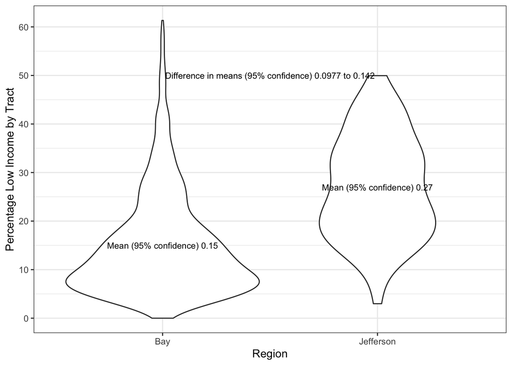

```r
ggplot(combined_data, aes(x = region, y = low_income)) +
  geom_violin() +
  theme_bw() +
  scale_x_discrete(name = "Region",
                   labels = c("Bay", "Jefferson")) +
   scale_y_continuous(name = "Percentage Low Income by Tract",
                     breaks = seq(0, 1, by = .1),
                     labels = paste(prettyNum(seq(0, 100, by = 10),
                                              big.mark = ","))) +
  annotate(geom = "text", x = 1.5, y = .5, size = 3,
           label = paste("Difference in means (95% confidence) ",
                         prettyNum(abs(difference2_combined$conf.int[2]),
                                   digits = 3), " to ",
                         prettyNum(abs(difference2_combined$conf.int[1]),
                                   digits = 3),
                         sep = "")) +
  annotate(geom = "text", x = 1, y = difference2_combined$estimate[1], size = 3,
           label = paste("Mean (95% confidence)",
                         prettyNum(difference2_combined$estimate[1], digits = 3))) +
  annotate(geom = "text", x = 2, y = difference2_combined$estimate[2], size = 3,
           label = paste("Mean (95% confidence)",
                         prettyNum(difference2_combined$estimate[2], digits = 3)))
```

[figure not shown]

```r
ggplot(combined_data, aes(x = county, y = low_income)) +
  geom_boxplot() +
  theme_bw() +
  theme(axis.text.x = element_text(angle = 90)) +
  scale_x_discrete(name = "County") +
  scale_y_continuous(name = "Population Below 100% Poverty Rate",
                     breaks = seq(0, 1, by = .1),
                     labels = paste(prettyNum(seq(0, 100, by = 10),
                                              big.mark = ",")))
```

##### Jefferson High School Graduation and Poverty

[figure not shown]

```r
ggplot(jefferson_data, aes(x = majority_grads, y =low_income)) +
  geom_violin() +
  theme_bw() +
  scale_x_discrete(name = "Jefferson Tract High School Graduation Rate: Meets or Exceeds 83%",
                   labels = c("Yes", "No")) +
   scale_y_continuous(name = "Jefferson Population Below 100% Poverty by Tract",
                     breaks = seq(0, 1, by = .1),
                     labels = paste(prettyNum(seq(0, 100, by = 10),
                                              big.mark = ","))) +
  annotate(geom = "text", x = 1.3,  y = .5, size = 4,
           label = paste("Difference in means (95% confidence) ",
                         prettyNum(abs(difference2_combined$conf.int[2]),
                                   digits = 3), " to ",
                         prettyNum(abs(difference2_combined$conf.int[1]),
                                   digits = 3),
                         sep = "")) +
  annotate(geom = "text", x = 1, y = difference2_jefferson$estimate[1], size = 3,
           label = paste("Mean (95% confidence)",
                         prettyNum(difference3_jefferson$estimate[1], digits = 3))) +
  annotate(geom = "text", x = 2, y = difference2_jefferson$estimate[2], size = 3,
           label = paste("Mean (95% confidence)",
                         prettyNum(difference2_jefferson$estimate[2], digits = 3)))
```